# **Summarization** strategy comparison for **Data-driven** analysis of isobarically labeled proteomic data.

Joris Van Houtven, Piotr Prostko

November 08, 2022,18:44

*This notebook is one in a series of many, where we explore how different data analysis strategies affect the outcome of a proteomics experiment based on isobaric labeling and mass spectrometry. Each analysis strategy or ‘workflow’ can be divided up into different components; it is recommend you read more about that in the introduction notebook.*

In this notebook specifically, we investigate the effect of varying the **Summarization** component on the outcome of the differential expression results. The three component variants are: **Median summarization**, **iPQF**, **Sum summarization**.

*The R packages and helper scripts necessary to run this notebook are listed in the next code chunk: click the ‘Code’ button. Each code section can be expanded in a similar fashion. You can also download the entire notebook source code.*

```r
library(stringi)
library(gridExtra)
library(dendextend)
library(kableExtra)
library(limma)
library(psych)
library(MSnbase)  # CAREFUL! load this BEFORE tidyverse, or you will screw up the rename function.
library(tidyverse)
source('util/other_functions.R')
source('util/plotting_functions.R')
```

Let’s load our PSM-level data set:

```r
data.list <- readRDS(params$input_data_p)
dat.l <- data.list$dat.l # data in long format
display_dataframe_head(dat.l)
```

| Mixture | TechRepMixture | Condition | BioReplicate | Run | Channel | Protein | Peptide | RT | Charge | PTM | intensity | TotalIntensity | Ions.Score | DeltaMZ | isoInterOk | noNAs | onehit.protein | shared.peptide |
| --- | --- | --- | --- | --- | --- | --- | --- | --- | --- | --- | --- | --- | --- | --- | --- | --- | --- | --- |
| Mixture2 | 1 | 1 | Mixture2_1 | Mixture2_1 | 127C | P21291 | [K].gFGFGQGAGALVHSE.[-] | 144.9444 | 2 | N-Term(TMT6plex) | 44048.41 | 394657.6 | 65 | 0.00052 | TRUE | TRUE | FALSE | FALSE |
| Mixture2 | 1 | 0.5 | Mixture2_0.5 | Mixture2_1 | 127N | P21291 | [K].gFGFGQGAGALVHSE.[-] | 144.9444 | 2 | N-Term(TMT6plex) | 38298.89 | 394657.6 | 65 | 0.00052 | TRUE | TRUE | FALSE | FALSE |
| Mixture2 | 1 | 0.125 | Mixture2_0.125 | Mixture2_1 | 128C | P21291 | [K].gFGFGQGAGALVHSE.[-] | 144.9444 | 2 | N-Term(TMT6plex) | 39552.81 | 394657.6 | 65 | 0.00052 | TRUE | TRUE | FALSE | FALSE |
| Mixture2 | 1 | 0.667 | Mixture2_0.667 | Mixture2_1 | 128N | P21291 | [K].gFGFGQGAGALVHSE.[-] | 144.9444 | 2 | N-Term(TMT6plex) | 56730.70 | 394657.6 | 65 | 0.00052 | TRUE | TRUE | FALSE | FALSE |
| Mixture2 | 1 | 0.667 | Mixture2_0.667 | Mixture2_1 | 129C | P21291 | [K].gFGFGQGAGALVHSE.[-] | 144.9444 | 2 | N-Term(TMT6plex) | 48744.49 | 394657.6 | 65 | 0.00052 | TRUE | TRUE | FALSE | FALSE |
| Mixture2 | 1 | 1 | Mixture2_1 | Mixture2_1 | 129N | P21291 | [K].gFGFGQGAGALVHSE.[-] | 144.9444 | 2 | N-Term(TMT6plex) | 60179.96 | 394657.6 | 65 | 0.00052 | TRUE | TRUE | FALSE | FALSE |

After the filtering done in `data_prep.R`, there are 19 UPS1 proteins remaining, even though 48 were originally spiked in.

```r
# which proteins were spiked in?
spiked.proteins <- dat.l %>% distinct(Protein) %>% filter(stri_detect(Protein, fixed='ups')) %>% pull %>% as.character
remove_factors(spiked.proteins)
```

```
##  [1] "P02787ups"   "P02788ups"   "P01133ups"   "P69905ups"   "P01008ups"   "P02741ups"   "P01375ups"
##  [8] "P10636-8ups" "O00762ups"   "P62988ups"   "P10145ups"   "P05413ups"   "P00915ups"   "P02753ups"
## [15] "P02144ups"   "P01344ups"   "P01579ups"   "P00709ups"   "P01127ups"
```

```r
tmp=dat.l %>% distinct(Protein) %>% pull %>% as.character
# protein subsampling
if (params$subsample_p>0 & params$subsample_p==floor(params$subsample_p) & params$subsample_p<=length(tmp)){
  sub.prot <- tmp[sample(1:length(tmp), size=params$subsample_p)]
  if (length(spiked.proteins)>0) sub.prot <- c(sub.prot,spiked.proteins)
  dat.l <- dat.l %>% filter(Protein %in% sub.prot)
}
```

We store the metadata in `sample.info` and show some entries below. We also pick technical replicates with a dilution factor of 0.5 as the reference condition of interest. Each condition is represented by two of eight reporter Channels in each Run.

```r
display_dataframe_head(sample.info)
```

| Run | Run.short | Channel | Sample | Sample.short | Condition | Color |
| --- | --- | --- | --- | --- | --- | --- |
| Mixture1_1 | Mix1_1 | 127C | Mixture1_1:127C | Mix1_1:127C | 0.125 | black |
| Mixture1_1 | Mix1_1 | 127N | Mixture1_1:127N | Mix1_1:127N | 0.667 | green |
| Mixture1_1 | Mix1_1 | 128C | Mixture1_1:128C | Mix1_1:128C | 1 | red |
| Mixture1_1 | Mix1_1 | 128N | Mixture1_1:128N | Mix1_1:128N | 0.5 | blue |
| Mixture1_1 | Mix1_1 | 129C | Mixture1_1:129C | Mix1_1:129C | 0.5 | blue |
| Mixture1_1 | Mix1_1 | 129N | Mixture1_1:129N | Mix1_1:129N | 0.125 | black |

```r
referenceCondition
```

```
## [1] "0.5"
```

```r
channelNames
```

```
## [1] "127C" "127N" "128C" "128N" "129C" "129N" "130C" "130N"
```

# 1 Unit scale component: log2 transformation of reporter ion intensities

We use the default unit scale: the log2-transformed reportion ion intensities.

```r
dat.unit.l <- dat.l %>% mutate(response=log2(intensity)) %>% select(-intensity)
display_dataframe_head(dat.unit.l)
```

| Mixture | TechRepMixture | Condition | BioReplicate | Run | Channel | Protein | Peptide | RT | Charge | PTM | TotalIntensity | Ions.Score | DeltaMZ | isoInterOk | noNAs | onehit.protein | shared.peptide | response |
| --- | --- | --- | --- | --- | --- | --- | --- | --- | --- | --- | --- | --- | --- | --- | --- | --- | --- | --- |
| Mixture2 | 1 | 1 | Mixture2_1 | Mixture2_1 | 127C | P21291 | [K].gFGFGQGAGALVHSE.[-] | 144.9444 | 2 | N-Term(TMT6plex) | 394657.6 | 65 | 0.00052 | TRUE | TRUE | FALSE | FALSE | 15.42680 |
| Mixture2 | 1 | 0.5 | Mixture2_0.5 | Mixture2_1 | 127N | P21291 | [K].gFGFGQGAGALVHSE.[-] | 144.9444 | 2 | N-Term(TMT6plex) | 394657.6 | 65 | 0.00052 | TRUE | TRUE | FALSE | FALSE | 15.22502 |
| Mixture2 | 1 | 0.125 | Mixture2_0.125 | Mixture2_1 | 128C | P21291 | [K].gFGFGQGAGALVHSE.[-] | 144.9444 | 2 | N-Term(TMT6plex) | 394657.6 | 65 | 0.00052 | TRUE | TRUE | FALSE | FALSE | 15.27149 |
| Mixture2 | 1 | 0.667 | Mixture2_0.667 | Mixture2_1 | 128N | P21291 | [K].gFGFGQGAGALVHSE.[-] | 144.9444 | 2 | N-Term(TMT6plex) | 394657.6 | 65 | 0.00052 | TRUE | TRUE | FALSE | FALSE | 15.79184 |
| Mixture2 | 1 | 0.667 | Mixture2_0.667 | Mixture2_1 | 129C | P21291 | [K].gFGFGQGAGALVHSE.[-] | 144.9444 | 2 | N-Term(TMT6plex) | 394657.6 | 65 | 0.00052 | TRUE | TRUE | FALSE | FALSE | 15.57295 |
| Mixture2 | 1 | 1 | Mixture2_1 | Mixture2_1 | 129N | P21291 | [K].gFGFGQGAGALVHSE.[-] | 144.9444 | 2 | N-Term(TMT6plex) | 394657.6 | 65 | 0.00052 | TRUE | TRUE | FALSE | FALSE | 15.87700 |

# 2 Normalization component: medianSweeping (1)

Median sweeping means subtracting from each PSM quantification value the spectrum median (i.e., the row median computed across samples/channels) and the sample median (i.e., the column median computed across features). If the unit scale is set to intensities or ratios, the multiplicative variant of this procedure is applied: subtraction is replaced by division.

Since median sweeping needs to be applied on matrix-like data, let’s switch to wide format. (Actually, this is semi-wide, since the Channel columns still have contributions form all Runs, but that’s OK because in the next step we split by Run.)

```r
# switch to wide format
dat.unit.w <- pivot_wider(data = dat.unit.l, id_cols=-one_of(c('Condition', 'BioReplicate')), names_from=Channel, values_from=response)
display_dataframe_head(dat.unit.w)
```

| Mixture | TechRepMixture | Run | Protein | Peptide | RT | Charge | PTM | TotalIntensity | Ions.Score | DeltaMZ | isoInterOk | noNAs | onehit.protein | shared.peptide | 127C | 127N | 128C | 128N | 129C | 129N | 130C | 130N |
| --- | --- | --- | --- | --- | --- | --- | --- | --- | --- | --- | --- | --- | --- | --- | --- | --- | --- | --- | --- | --- | --- | --- |
| Mixture2 | 1 | Mixture2_1 | P21291 | [K].gFGFGQGAGALVHSE.[-] | 144.9444 | 2 | N-Term(TMT6plex) | 394657.56 | 65 | 0.00052 | TRUE | TRUE | FALSE | FALSE | 15.42680 | 15.22502 | 15.27149 | 15.79184 | 15.57295 | 15.87700 | 15.71883 | 15.69836 |
| Mixture2 | 1 | Mixture2_1 | P30511 | [K].wAAVVVPPGEEQR.[Y] | 137.1704 | 2 | N-Term(TMT6plex) | 180359.11 | 27 | -0.00653 | TRUE | TRUE | TRUE | FALSE | 14.36513 | 14.14964 | 14.27690 | 14.65920 | 14.44955 | 14.58652 | 14.54510 | 14.57900 |
| Mixture2 | 1 | Mixture2_1 | P02787ups | [K].sASDLTWDNLk.[G] | 148.8299 | 3 | N-Term(TMT6plex); K11(TMT6plex) | 507218.12 | 35 | -0.00005 | TRUE | TRUE | FALSE | FALSE | 16.31046 | 15.32833 | 15.11530 | 16.27180 | 15.92615 | 16.73355 | 15.74796 | 15.42268 |
| Mixture2 | 1 | Mixture2_1 | Q9UBQ5 | [K].iDFDSVSSIMASSQ.[-] | 201.8727 | 2 | N-Term(TMT6plex) | 120944.32 | 72 | 0.00119 | TRUE | TRUE | FALSE | FALSE | 13.51956 | 13.51995 | 13.66172 | 14.36018 | 13.87050 | 14.20738 | 13.86685 | 13.83673 |
| Mixture2 | 1 | Mixture2_1 | Q5H9R7 | [R].tGQPSAPGDTSVNGPV.[-] | 106.9002 | 2 | N-Term(TMT6plex) | 99098.46 | 23 | -0.00133 | TRUE | TRUE | FALSE | FALSE | 13.54513 | 13.17495 | 13.34133 | 13.81323 | 13.58510 | 14.02262 | 13.60511 | 13.51803 |
| Mixture2 | 1 | Mixture2_1 | P43490 | [K].nAQLNIELEAAHH.[-] | 99.8437 | 3 | N-Term(TMT6plex) | 497023.17 | 15 | 0.00061 | TRUE | TRUE | FALSE | FALSE | 15.58965 | 15.43193 | 15.86127 | 16.18651 | 15.86677 | 16.28384 | 15.93733 | 16.03418 |

First, let’s sweep the medians of all the rows, and do the columns later as suggested by [Herbrich at al.](https://doi.org/10.1021/pr300624g). No need to split this per Run, because each row in this semi-wide format contains only values from one Run and each median calculation is independent of the other rows.

```r
# subtract the spectrum median log2intensity from the observed log2intensities
dat.norm.w <- dat.unit.w
dat.norm.w[,channelNames] <- median_sweep(dat.norm.w[,channelNames], 1, '-')
display_dataframe_head(dat.norm.w)
```

| Mixture | TechRepMixture | Run | Protein | Peptide | RT | Charge | PTM | TotalIntensity | Ions.Score | DeltaMZ | isoInterOk | noNAs | onehit.protein | shared.peptide | 127C | 127N | 128C | 128N | 129C | 129N | 130C | 130N |
| --- | --- | --- | --- | --- | --- | --- | --- | --- | --- | --- | --- | --- | --- | --- | --- | --- | --- | --- | --- | --- | --- | --- |
| Mixture2 | 1 | Mixture2_1 | P21291 | [K].gFGFGQGAGALVHSE.[-] | 144.9444 | 2 | N-Term(TMT6plex) | 394657.56 | 65 | 0.00052 | TRUE | TRUE | FALSE | FALSE | -0.2088531 | -0.4106403 | -0.3641628 | 0.1561868 | -0.0627039 | 0.2413401 | 0.0831727 | 0.0627039 |
| Mixture2 | 1 | Mixture2_1 | P30511 | [K].wAAVVVPPGEEQR.[Y] | 137.1704 | 2 | N-Term(TMT6plex) | 180359.11 | 27 | -0.00653 | TRUE | TRUE | TRUE | FALSE | -0.1321964 | -0.3476832 | -0.2204273 | 0.1618711 | -0.0477788 | 0.0891915 | 0.0477788 | 0.0816737 |
| Mixture2 | 1 | Mixture2_1 | P02787ups | [K].sASDLTWDNLk.[G] | 148.8299 | 3 | N-Term(TMT6plex); K11(TMT6plex) | 507218.12 | 35 | -0.00005 | TRUE | TRUE | FALSE | FALSE | 0.4734048 | -0.5087304 | -0.7217574 | 0.4347442 | 0.0890943 | 0.8964941 | -0.0890943 | -0.4143805 |
| Mixture2 | 1 | Mixture2_1 | Q9UBQ5 | [K].iDFDSVSSIMASSQ.[-] | 201.8727 | 2 | N-Term(TMT6plex) | 120944.32 | 72 | 0.00119 | TRUE | TRUE | FALSE | FALSE | -0.3322250 | -0.3318356 | -0.1900625 | 0.5083959 | 0.0187098 | 0.3555902 | 0.0150596 | -0.0150596 |
| Mixture2 | 1 | Mixture2_1 | Q5H9R7 | [R].tGQPSAPGDTSVNGPV.[-] | 106.9002 | 2 | N-Term(TMT6plex) | 99098.46 | 23 | -0.00133 | TRUE | TRUE | FALSE | FALSE | -0.0199852 | -0.3901617 | -0.2237788 | 0.2481239 | 0.0199852 | 0.4575068 | 0.0399986 | -0.0470807 |
| Mixture2 | 1 | Mixture2_1 | P43490 | [K].nAQLNIELEAAHH.[-] | 99.8437 | 3 | N-Term(TMT6plex) | 497023.17 | 15 | 0.00061 | TRUE | TRUE | FALSE | FALSE | -0.3124028 | -0.4701170 | -0.0407846 | 0.2844554 | -0.0352769 | 0.3817914 | 0.0352769 | 0.1321293 |

These (partially) normalized quantification values are now already comparable, but after summarization we will also sweep the columns on the protein level, as suggested by [Herbrich at al.](https://doi.org/10.1021/pr300624g).

# 3 Summarization component

In the next three subsections, let’s look at our different ways to summarize quantification values from PSM to peptide (first step) to protein (second step) in each sample.

```r
dat.norm.summ.w <- emptyList(variant.names)
dat.nonnorm.summ.w <- emptyList(variant.names)
```

## 3.1 Median summarization

Median summarization is simple: within each Run and within each Channel, we replace multiple related observations with their median. First, for each Peptide (median of the PSM values), then for each Protein (median of the peptide values).

```r
median_summarization <- function(dat) {
  # group by (run,)protein,peptide then summarize twice (once on each level)
  # add select() statement because summarise_at is going bananas over character columns
  return(dat %>% group_by(Run, Protein, Peptide) %>% select(Run, Protein, Peptide, channelNames) %>% summarise(across(channelNames, .fns = median)) %>% select(Run, Protein, channelNames) %>% summarise(across(channelNames, .fns = median)) %>% ungroup())
}

# normalized data
dat.norm.summ.w$median <- median_summarization(dat.norm.w)
display_dataframe_head(dat.norm.summ.w$median[, channelNames])
```

| 127C | 127N | 128C | 128N | 129C | 129N | 130C | 130N |
| --- | --- | --- | --- | --- | --- | --- | --- |
| -0.4092298 | -0.1673011 | 0.2141415 | 0.3318794 | 0.2110937 | -0.0030274 | 0.0030274 | -0.4648726 |
| -0.5248261 | -0.0762095 | 0.3164919 | 0.1996797 | 0.0311662 | 0.0681443 | 0.0185818 | -0.6414210 |
| -0.4006406 | -0.2139570 | 0.3876424 | 0.3337212 | 0.2583116 | -0.0188944 | 0.0188944 | -0.4659382 |
| -0.2285656 | -0.1436318 | 0.0574925 | 0.3790593 | 0.3363888 | 0.2180016 | -0.0574925 | -0.3891581 |
| 0.1427990 | -0.1600185 | 0.7483754 | 0.1524052 | -0.4018839 | -0.0658215 | 0.0658215 | -0.9682449 |
| -0.2304093 | -0.3565971 | 0.1488981 | 0.3135104 | 0.0583539 | -0.0485547 | 0.0485547 | -0.5092703 |

Let’s also summarize the non-normalized data for comparison later on.

```r
# non-normalized data
dat.nonnorm.summ.w$median <- median_summarization(dat.unit.w)
```

## 3.2 iPQF

iPQF uses several quantitative *and* qualitative peptide spectral characteristics to compute a weighted mean to approximate protein abundance. This means it can summarize directly from PSM to protein level while taking into account “features such as charge state, sequence length, identification score, mass and a distance metric within uniquely and redundantly measured spectra”. As iPQF is easiest to use through MSnbase, we first turn each MS run in our data set into an MSnSet object and then use the `combineFeatures` function with the iPQF option.

```r
iPQF_summarization <- function(x) {
  dat <- split(x, x$Run)  # apply iPQF to each Run separately
  # first make an MSnSet object
  exprs <- lapply(dat, function(y) as.matrix(y[,channelNames]))
  fdata <- lapply(dat, function(y) as.data.frame(y %>% select(-channelNames)) %>% rename(sequence='Peptide', accession='Protein', charge='Charge', modifications='PTM', mass_to_charge='DeltaMZ', search_engine_score='Ions.Score', Intensity='TotalIntensity'))
  mss <- emptyList(names(dat))
  for (i in seq_along(mss)) { mss[[i]] <- MSnSet(exprs = exprs[[i]], fData = fdata[[i]]) }
  # then summarize
  mss.norm <- lapply(mss, function(y) combineFeatures(y, method='iPQF', groupBy = fData(y)$accession, ratio.calc='none'))
  mss.norm.tibble <- lapply(mss.norm, function(y) tibble(cbind(data.frame(Run=fData(y)$Run), rownames_to_column(as.data.frame(exprs(y)), var='Protein'))))
  return(bind_rows(mss.norm.tibble))
}
# normalized data
dat.norm.summ.w$iPQF <- iPQF_summarization(dat.norm.w)
display_dataframe_head(dat.norm.summ.w$iPQF[, channelNames])
```

| 127C | 127N | 128C | 128N | 129C | 129N | 130C | 130N |
| --- | --- | --- | --- | --- | --- | --- | --- |
| -0.4341550 | -0.1700689 | 0.2599970 | 0.3723777 | 0.2029793 | -0.0005341 | 0.0003044 | -0.4528157 |
| -0.5577097 | -0.0756276 | 0.3076754 | 0.1813082 | 0.0238412 | 0.0926545 | 0.0006281 | -0.6809088 |
| -0.4006406 | -0.2139570 | 0.3876424 | 0.3337212 | 0.2583116 | -0.0188944 | 0.0188944 | -0.4659382 |
| -0.2285656 | -0.1436318 | 0.0574925 | 0.3790593 | 0.3363888 | 0.2180016 | -0.0574925 | -0.3891581 |
| 0.1427990 | -0.1600185 | 0.7483754 | 0.1524052 | -0.4018839 | -0.0658215 | 0.0658215 | -0.9682449 |
| -0.2304093 | -0.3565971 | 0.1488981 | 0.3135104 | 0.0583539 | -0.0485547 | 0.0485547 | -0.5092703 |

Here, too, let’s summarize the non-normalized data for comparison later on.

```r
# non-normalized data
dat.nonnorm.summ.w$iPQF <- iPQF_summarization(dat.unit.w)
```

## 3.3 Sum summarization

Sum summarization is completely analogous to the Median summarization, except that we sum values instead of taking the median. Note that sum normalization is *not* equivalent to mean normalization: yes, rows containing NA values are removed, but there may be multiple PSMs per peptide and multiple peptides per protein. Since we know that there is a strong peptide-run interaction, summing values across peptides per protein may result in strong bias by run.

```r
sum_summarization <- function(dat) {
  # group by (run,)protein,peptide then summarize twice (once on each level)
  # add select() statement because summarise_at is going bananas over character columns
  return(dat %>% group_by(Run, Protein, Peptide) %>% select(Run, Protein, Peptide, channelNames) %>% summarise(across(channelNames, .fns = sum)) %>% select(Run, Protein, channelNames) %>% summarise(across(channelNames, .fns = sum)) %>% ungroup())
}
# normalized data
dat.norm.summ.w$sum <- sum_summarization(dat.norm.w)
display_dataframe_head(dat.norm.summ.w$sum[, channelNames])
```

| 127C | 127N | 128C | 128N | 129C | 129N | 130C | 130N |
| --- | --- | --- | --- | --- | --- | --- | --- |
| -3.3745770 | -1.2512419 | 1.6393313 | 2.5813761 | 1.2186853 | -0.0528255 | 0.0813142 | -3.4513748 |
| -2.2370267 | -0.4144577 | 1.1292273 | 0.6625648 | 0.1962396 | 0.2949377 | 0.0176503 | -2.6657243 |
| -0.8012813 | -0.4279141 | 0.7752849 | 0.6674423 | 0.5166232 | -0.0377888 | 0.0377888 | -0.9318764 |
| -0.2285656 | -0.1436318 | 0.0574925 | 0.3790593 | 0.3363888 | 0.2180016 | -0.0574925 | -0.3891581 |
| 0.1427990 | -0.1600185 | 0.7483754 | 0.1524052 | -0.4018839 | -0.0658215 | 0.0658215 | -0.9682449 |
| -0.2304093 | -0.3565971 | 0.1488981 | 0.3135104 | 0.0583539 | -0.0485547 | 0.0485547 | -0.5092703 |

Again, let’s also summarize the non-normalized data for comparison later on.

```r
# non-normalized data
dat.nonnorm.summ.w$sum <- sum_summarization(dat.unit.w)
```

# 4 Normalization component: medianSweeping (2)

```r
# medianSweeping: in each channel, subtract median computed across all proteins within the channel
# do the above separately for each MS run
dat.norm.summ.w <- lapply(dat.norm.summ.w, function(x) {
  x.split <- split(x, x$Run)
  x.split.norm  <- lapply(x.split, function(y) {
    y[,channelNames] <- median_sweep(y[,channelNames], 2, '-')
    return(y)})
  dat.norm.summ.w <- bind_rows(x.split.norm)
})
```

# 5 QC plots

Before getting to the DEA section, let’s do some basic quality control and take a sneak peek at the differences between the component variants we’ve chosen. First, however, we should make the data completely wide, so that each sample gets it’s own unique column.

```r
# make data completely wide (also across runs)
## normalized data
dat.norm.summ.w2 <- lapply(dat.norm.summ.w, function(x) {
  return(x %>% pivot_wider(names_from = Run, values_from = all_of(channelNames), names_glue = "{Run}:{.value}"))
})
colnames(dat.norm.summ.w2$median)
```

```
##  [1] "Protein"         "Mixture1_1:127C" "Mixture1_2:127C" "Mixture2_1:127C" "Mixture2_2:127C"
##  [6] "Mixture1_1:127N" "Mixture1_2:127N" "Mixture2_1:127N" "Mixture2_2:127N" "Mixture1_1:128C"
## [11] "Mixture1_2:128C" "Mixture2_1:128C" "Mixture2_2:128C" "Mixture1_1:128N" "Mixture1_2:128N"
## [16] "Mixture2_1:128N" "Mixture2_2:128N" "Mixture1_1:129C" "Mixture1_2:129C" "Mixture2_1:129C"
## [21] "Mixture2_2:129C" "Mixture1_1:129N" "Mixture1_2:129N" "Mixture2_1:129N" "Mixture2_2:129N"
## [26] "Mixture1_1:130C" "Mixture1_2:130C" "Mixture2_1:130C" "Mixture2_2:130C" "Mixture1_1:130N"
## [31] "Mixture1_2:130N" "Mixture2_1:130N" "Mixture2_2:130N"
```

```r
## non-normalized data
dat.nonnorm.summ.w2 <- lapply(dat.nonnorm.summ.w, function(x){
  return(x %>% pivot_wider(names_from = Run, values_from = all_of(channelNames), names_glue = "{Run}:{.value}") )
})
```

## 5.1 Boxplots

These boxplots of both the raw and normalized intensities show that the distributions of Median- and iPQF-summarized values are very similar and symmetrical. In contrast, the Sum summarization produces very skewed distributions. Although for all summarization methods the boxplots are centered after normalization, this skewness of the Sum summarized values is ominous.

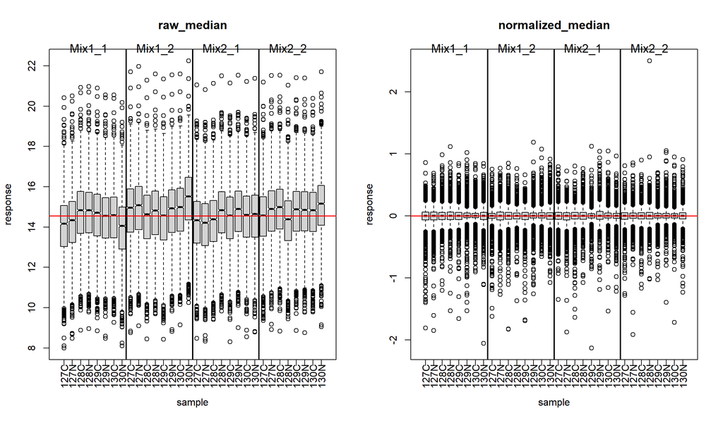

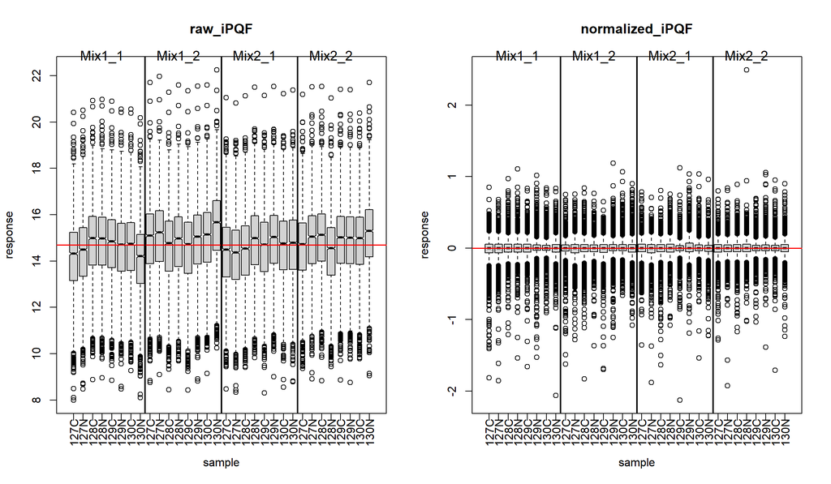

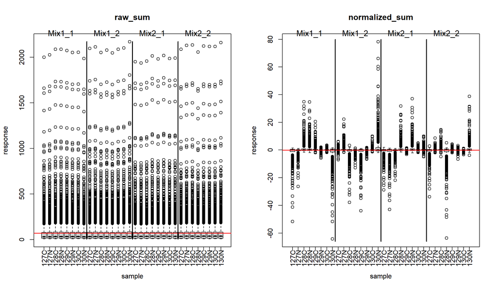

```r
# use (half-)wide format
par(mfrow=c(1,2))
for (i in 1:n.comp.variants){
  boxplot_w(dat.nonnorm.summ.w[[variant.names[i]]],sample.info, paste('raw', variant.names[i], sep='_'))
  boxplot_w(dat.norm.summ.w[[variant.names[i]]], sample.info, paste('normalized', variant.names[i], sep='_'))}
```

## 5.2 MA plots

Remarkably, the raw, Sum summarized values exhibit artifacts: clusters near the lower end of the A axis. This hints at a hidden incompatibility: additive median sweeping (which we apply to $\log_2$-scale data) produces negative values - on the PSM level already - which actually reduce the grand sum of intensities instead of strictly increasing them. The clusters represent the discrete number of combinations - on the protein level - of some number of positive values with some number of negative values. The proteins near the lowest extreme of the M axis are likely represented by only one peptide, meaning their fold changes (A-axis) have contributions from (in the simplest case) only one PSM. This means both the denominator and enumerator are likely two similarly-sized values. The next clusters, for instance, are not on the M-axis but above and below, as they probably contain contributions from, e.g., 2 PSMs (from the same peptide or not) where one contributes two quantification values with the same sign, and the other one two values with an opposite sign, generating MA values strictly above or below the M axis. The effect becomes less discrete as M increases and more PSMs and thus more quantification values get involved, reducing the stochasticity.

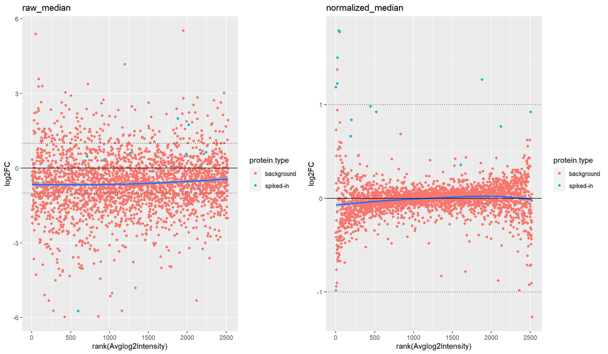

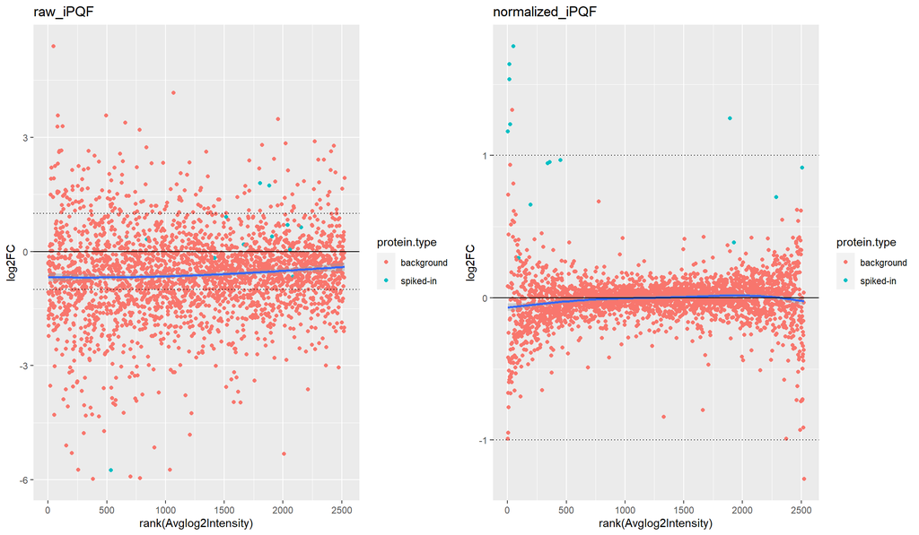

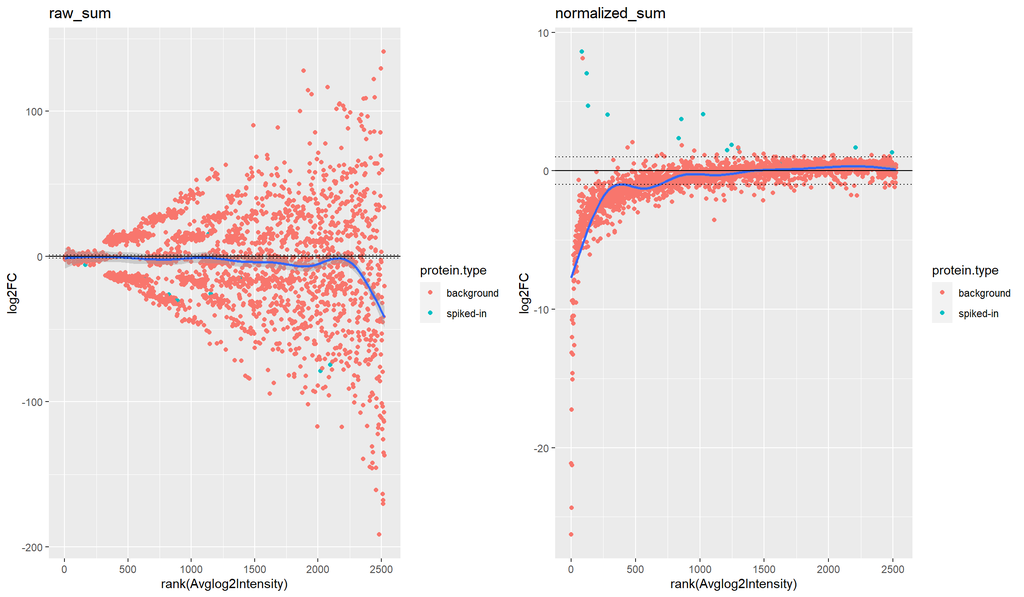

```r
for (i in 1:n.comp.variants){
  p1 <- maplot_ils(dat.nonnorm.summ.w2[[variant.names[i]]], ma.onesample.num, ma.onesample.denom, scale.vec, paste('raw', variant.names[i], sep='_'), spiked.proteins)
  p2 <- maplot_ils(dat.norm.summ.w2[[variant.names[i]]], ma.onesample.num, ma.onesample.denom, scale.vec, paste('normalized', variant.names[i], sep='_'), spiked.proteins)
grid.arrange(p1, p2, ncol=2)}
```

To increase the robustness of these results, let’s make some more MA plots, but now for all samples from condition 0.5 and condition 0.125 (quantification values averaged within condition). Indeed, even the raw, unnormalized data now show less variability, and again even more so for the Median summarization normalized data.

It seems that by using more samples (now 8 in both the enumerator and denominator instead of just one) in the fold change calculation the rolling average is more robust and the Sum summarization data bias has been reduced (but not disappeared). This is also supported by the fact that the anomalies due to stochasticity in the raw Sum summarization plot have disappeared.

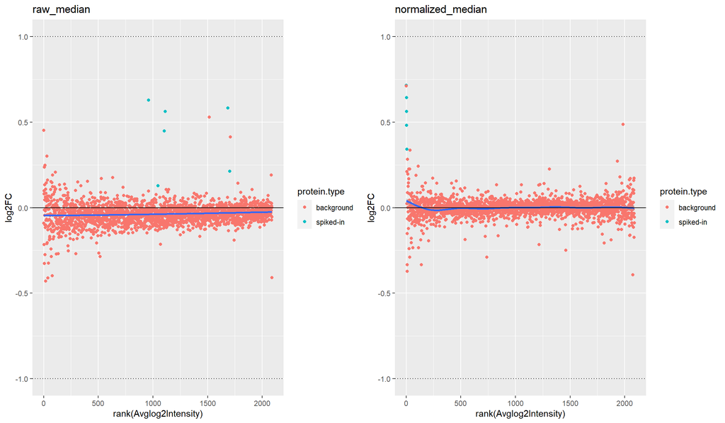

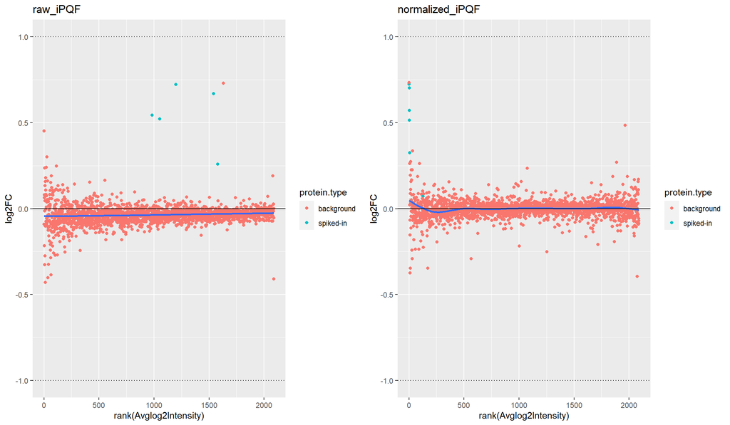

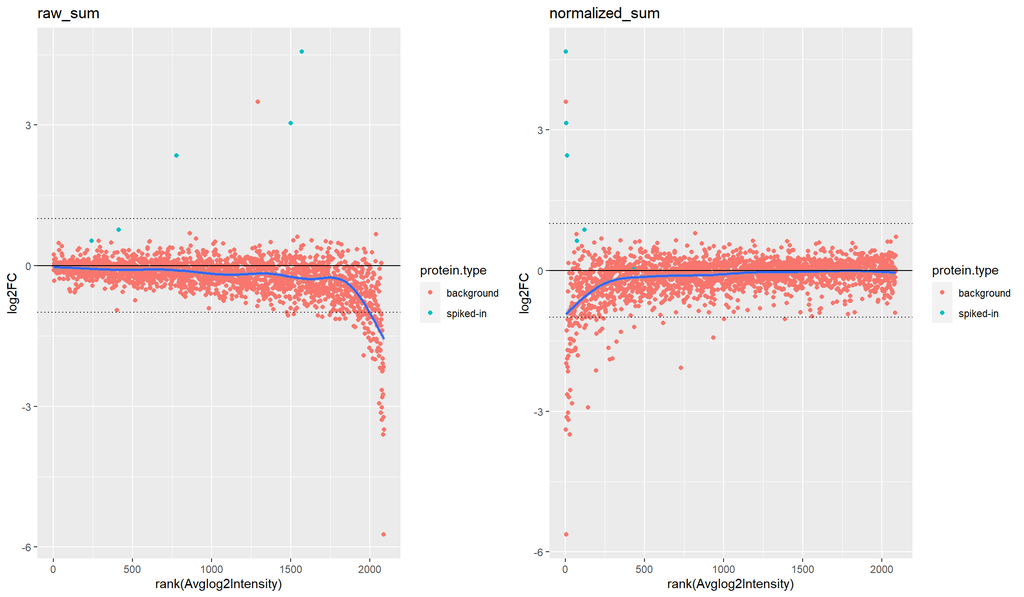

```r
channels.num <- sample.info %>% filter(Condition==ma.allsamples.num) %>% select(Sample) %>% pull
channels.denom <- sample.info %>% filter(Condition==ma.allsamples.denom) %>% select(Sample) %>% pull
for (i in 1:n.comp.variants){
  p1 <- maplot_ils(dat.nonnorm.summ.w2[[variant.names[i]]], channels.num, channels.denom, scale=scale.vec, paste('raw', variant.names[i], sep='_'), spiked.proteins)
  p2 <- maplot_ils(dat.norm.summ.w2[[variant.names[i]]], channels.num, channels.denom, scale=scale.vec, paste('normalized', variant.names[i], sep='_'), spiked.proteins)
grid.arrange(p1, p2, ncol=2)}
```

## 5.3 PCA plots

Now, let’s check if these multi-dimensional data contains some kind of grouping; It’s time to make PCA plots. Even though PC1 does seem to capture the conditions, providing a gradient for the dilution number, only the 0.125 condition is completely separable in the normalized data. Here, clearly the Sum summarization is insufficient and does not get further than merely scrambling the samples and not leaving them clustered according to run.

### 5.3.1 Using all proteins

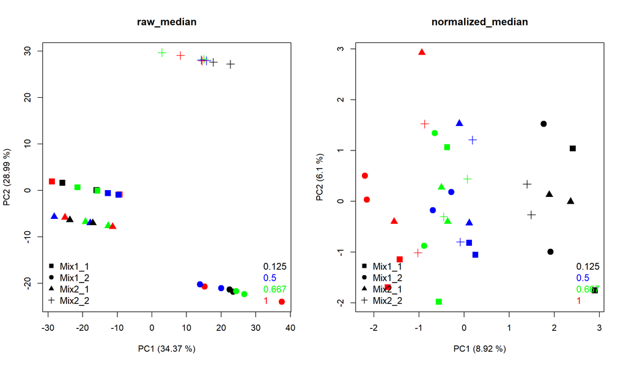

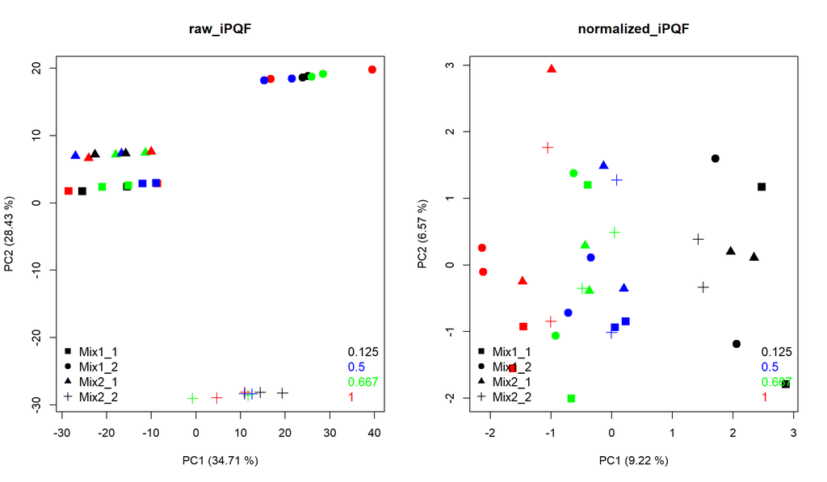

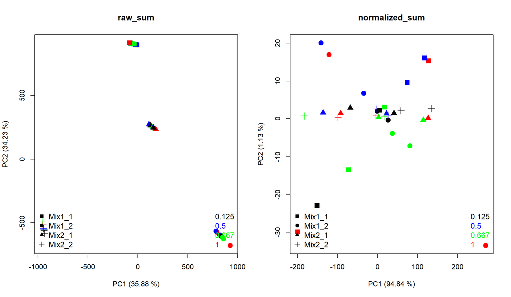

```r
par(mfrow=c(1,2))
for (i in 1:n.comp.variants){
  pcaplot_ils(dat.nonnorm.summ.w2[[variant.names[i]]] %>% select(-'Protein'), info=sample.info, paste('raw', variant.names[i], sep='_'))
  pcaplot_ils(dat.norm.summ.w2[[variant.names[i]]] %>% select(-'Protein'), info=sample.info, paste('normalized', variant.names[i], sep='_'))}
```

There are only 19 proteins supposed to be differentially expressed in this data set, which is only a very small amount in both relative (to the 4083 proteins total) and absolute (for a biological sample) terms.

### 5.3.2 Using spiked proteins only

Therefore, let’s see what the PCA plots look like if we were to only use the spiked proteins in the PCA. Now, there are clear differences between the raw or non-normalized Median and iPQF) plots, but *after* normalization they are very similar! This time, the separation between different conditions has become more distinct, which suggests the experiment was carried out successfully. Even here, Sum summarization does not properly separate the samples according to condition.

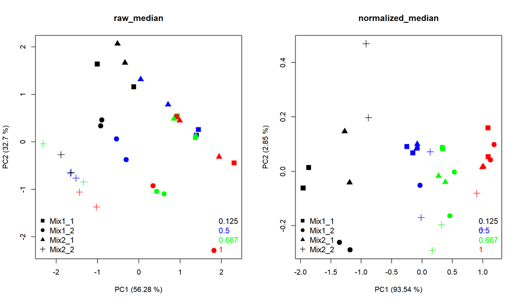

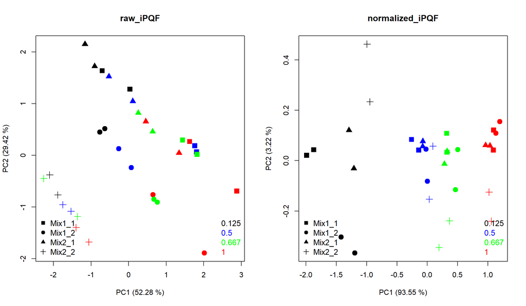

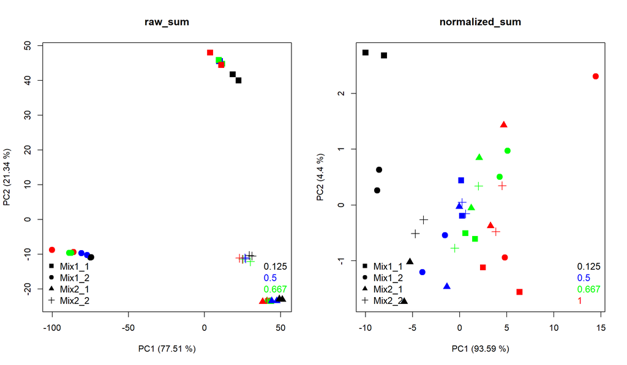

```r
par(mfrow=c(1,2))
for (i in 1:n.comp.variants){
  pcaplot_ils(dat.nonnorm.summ.w2[[variant.names[i]]] %>% filter(Protein %in% spiked.proteins) %>% select(-'Protein'), info=sample.info, paste('raw', variant.names[i], sep='_'))
  pcaplot_ils(dat.norm.summ.w2[[variant.names[i]]] %>% filter(Protein %in% spiked.proteins) %>% select(-'Protein'), info=sample.info, paste('normalized', variant.names[i], sep='_'))}
```

## 5.4 HC (hierarchical clustering) plots

The PCA plots of all proteins has a rather lower fraction of variance explained by PC1. We can confirm this using the hierarchical clustering dendrograms below: when considering the entire multidimensional space, the different conditions are not very separable at all. This is not surprising as there is little biological variation between the conditions: there are only 19 truly differential proteins, and they all (ought to) covary in exactly the same manner (i.e., their variation can be captured in one dimension).

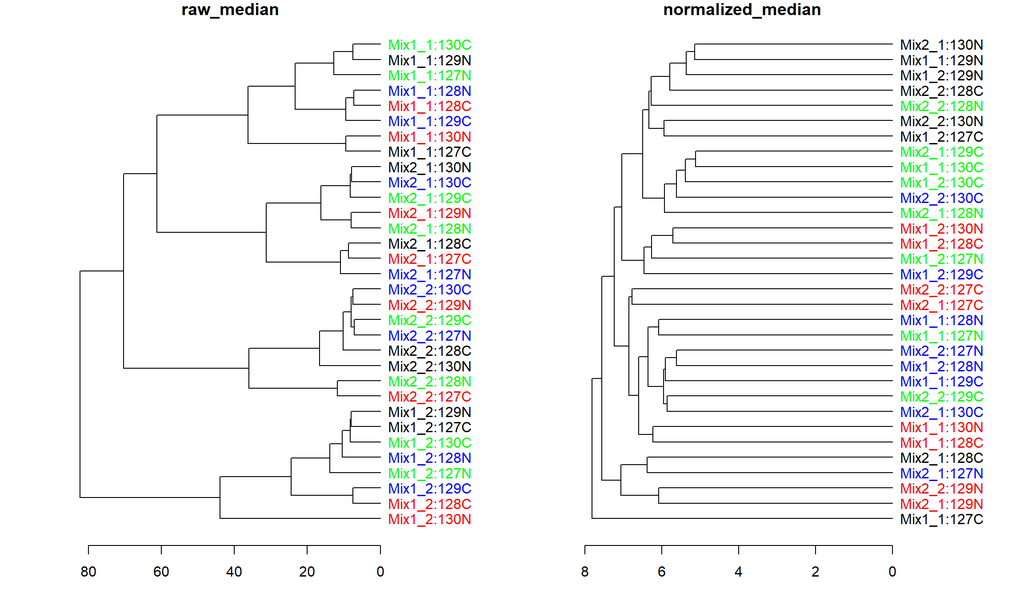

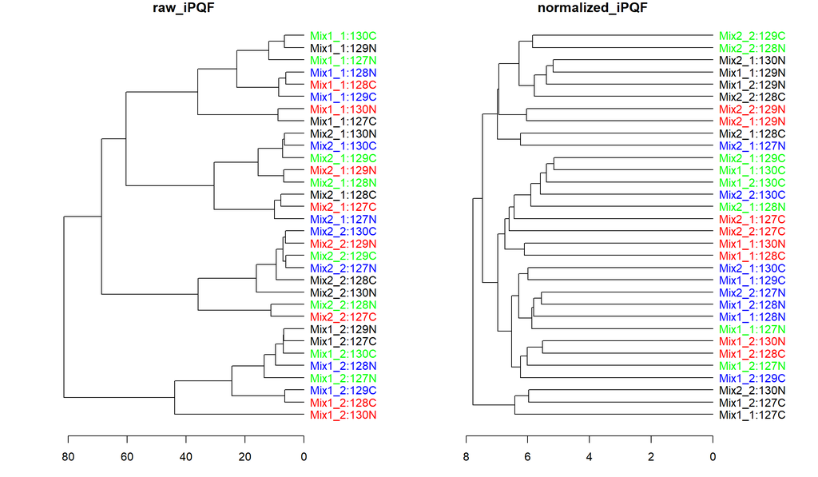

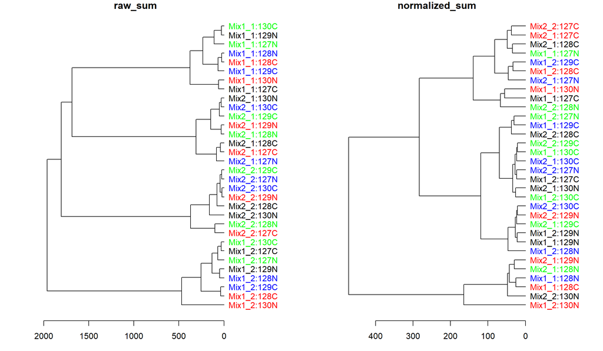

```r
par(mfrow=c(1,2))
for (i in 1:n.comp.variants){
  dendrogram_ils(dat.nonnorm.summ.w2[[variant.names[i]]] %>% select(-Protein), info=sample.info, paste('raw', variant.names[i], sep='_'))
  dendrogram_ils(dat.norm.summ.w2[[variant.names[i]]] %>% select(-Protein), info=sample.info, paste('normalized', variant.names[i], sep='_'))}
```

## 5.5 Run effect p-value plot

Our last quality check involves a measure of how well each variant was able to assist in removing the run effect. Below are the distributions of p-values from a linear model for the `response` variable with `Run` as a covariate. If the run effect was removed successfully, these p-values ought to be large. Clearly, the raw data contains a run effect, which is partially removed by the normalization when using Median or iPQF summarization and - surprisingly - even better when using Sum summarization. The latter may be a consequence of the fact that this experiment was carried out very carefully: the sample sizes are near-identical and the simulated variance we added averages out across multiple samples, rendering the total summed intensities of proteins more or less stable across runs.

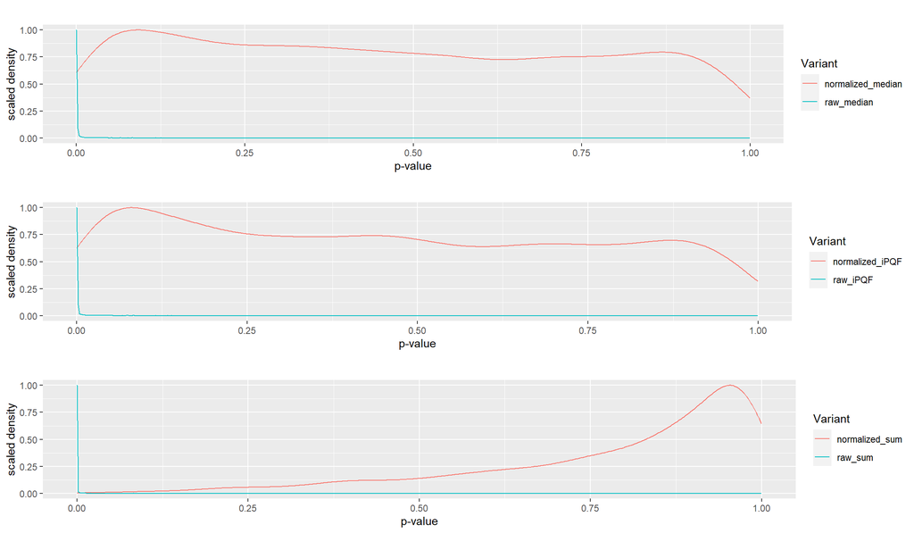

```r
plots <- vector('list', n.comp.variants)
for (i in 1:n.comp.variants){
dat <- list(dat.nonnorm.summ.l[[variant.names[i]]], dat.norm.summ.l[[variant.names[i]]])
names(dat) <- c(paste('raw', variant.names[i], sep='_'), paste('normalized', variant.names[i], sep='_'))
plots[[i]] <- run_effect_plot(dat)}
grid.arrange(grobs = plots, nrow=n.comp.variants)
```

# 6 DEA component: Moderated t-test

To check whether these fold changes are significant (criterium: $q<0.05$), we use a [moderated t-test](http://www.biostat.jhsph.edu/~kkammers/software/eupa/R_guide.html) slightly adapted from the `limma` package, which in use cases like ours should improve statistical power over a regular t-test. In a nutshell, this is a t-test done independently for each protein, although the variance used in the calculation of the t-statistic is [moderated using some empirical Bayes estimation](https://doi.org/10.2202/1544-6115.1027). After testing, we make a correction for multiple testing using the Benjamini-Hochberg method in order to keep the FDR under control.

```r
# design matrix as used in ANOVA testing.
design.matrix <- get_design_matrix(referenceCondition, sample.info)
dat.dea <- emptyList(names(dat.norm.summ.w2))
for (i in 1:n.comp.variants){
  # provide scale so moderated_ttest knows whether you input log2 or raw intensities.
  this_scale <- scale.vec
  d <- column_to_rownames(as.data.frame(dat.norm.summ.w2[[variant.names[i]]]), 'Protein')
  dat.dea[[variant.names[i]]] <- moderated_ttest(dat=d, design.matrix, scale=this_scale)}
```

For each condition, we now get the fold changes, moderated and unmoderated p-values, moderated and unmoderated q-values (BH-adjusted p-values), and some other details (head of dataframe below).

```r
display_dataframe_head(dat.dea[[1]])
```

|  | logFC_0.125 | logFC_0.667 | logFC_1 | t.ord_0.125 | t.ord_0.667 | t.ord_1 | t.mod_0.125 | t.mod_0.667 | t.mod_1 | p.ord_0.125 | p.ord_0.667 | p.ord_1 | p.mod_0.125 | p.mod_0.667 | p.mod_1 | q.ord_0.125 | q.ord_0.667 | q.ord_1 | q.mod_0.125 | q.mod_0.667 | q.mod_1 | df.r | df.0 | s2.0 | s2 | s2.post |
| --- | --- | --- | --- | --- | --- | --- | --- | --- | --- | --- | --- | --- | --- | --- | --- | --- | --- | --- | --- | --- | --- | --- | --- | --- | --- | --- |
| A0AVT1 | -0.0296332 | -0.0190075 | 0.0086228 | -1.2236300 | -0.7848676 | 0.3560550 | -1.1698892 | -0.7503969 | 0.3404173 | 0.2312896 | 0.4391218 | 0.7244682 | 0.2512504 | 0.4588575 | 0.7359131 | 0.9569613 | 0.9960123 | 0.9898622 | 0.9350748 | 0.9805978 | 0.9840728 | 28 | 2.018963 | 0.0056242 | 0.0023459 | 0.0025664 |
| A0FGR8 | 0.0121287 | 0.0389655 | 0.0247813 | 0.3627376 | 1.1653597 | 0.7411452 | 0.3596350 | 1.1553923 | 0.7348061 | 0.7195248 | 0.2537054 | 0.4647764 | 0.7216378 | 0.2570437 | 0.4681594 | 0.9841943 | 0.9960123 | 0.9820911 | 0.9795638 | 0.9723943 | 0.9650451 | 28 | 2.018963 | 0.0056242 | 0.0044720 | 0.0045495 |
| A0MZ66 | 0.0035130 | -0.0009938 | -0.0183834 | 0.0761086 | -0.0215311 | -0.3982773 | 0.0769941 | -0.0217816 | -0.4029113 | 0.9398739 | 0.9829747 | 0.6934465 | 0.9391391 | 0.9827663 | 0.6898687 | 0.9978394 | 0.9975071 | 0.9898622 | 0.9964971 | 0.9975410 | 0.9825206 | 28 | 2.018963 | 0.0056242 | 0.0085220 | 0.0083271 |
| A1L0T0 | 0.0520381 | -0.0328378 | -0.0500166 | 0.7951963 | -0.5017969 | -0.7643056 | 0.8165216 | -0.5152539 | -0.7848025 | 0.4358354 | 0.6212896 | 0.4536089 | 0.4229483 | 0.6115101 | 0.4409319 | 0.9569613 | 0.9975071 | 0.9820911 | 0.9350748 | 0.9924981 | 0.9650451 | 20 | 2.018963 | 0.0056242 | 0.0128474 | 0.0121851 |
| A3KMH1 | 0.4342224 | 0.3206653 | 0.5484563 | 1.7510253 | 1.2931002 | 2.2116798 | 1.8344616 | 1.3547163 | 2.3170662 | 0.0952654 | 0.2107143 | 0.0387933 | 0.0801348 | 0.1892462 | 0.0301887 | 0.9569613 | 0.9960123 | 0.7960743 | 0.9350748 | 0.9540539 | 0.7680706 | 20 | 2.018963 | 0.0056242 | 0.1844849 | 0.1680848 |
| A4D1E9 | -0.0219254 | -0.0731552 | -0.0426655 | -0.4771987 | -1.5921945 | -0.9285977 | -0.4796669 | -1.6004298 | -0.9334006 | 0.6383938 | 0.1270236 | 0.3641701 | 0.6361944 | 0.1237544 | 0.3607366 | 0.9741019 | 0.9841938 | 0.9820911 | 0.9644451 | 0.9260254 | 0.9650451 | 20 | 2.018963 | 0.0056242 | 0.0063331 | 0.0062681 |

# 7 Results comparison

Now, the most important part: let’s find out how our component variants have affected the outcome of the DEA.

## 7.1 Confusion matrix

A confusion matrix shows how many true and false positives/negatives each variant has given rise to. Spiked proteins that are DE are true positives, background proteins that are not DE are true negatives. We calculate this matrix for all conditions and then calculate some other informative metrics based on the confusion matrices: accuracy, sensitivity, specificity, positive predictive value and negative predictive value.

Clearly, across the board, Sum summarization underperforms while Median summarization and iPQF are on equal footing, with an acceptable but not spectacular sensitivity. That said, the contrast between conditions 0.667 and 0.5 seems not large enough to yield many significant results.

```r
cm <- conf_mat(dat.dea, 'q.mod', 0.05, spiked.proteins)
print_conf_mat(cm, referenceCondition)
```

|  | 0.125 vs 0.5 contrast median background | 0.125 vs 0.5 contrast median spiked | 0.125 vs 0.5 contrast iPQF background | 0.125 vs 0.5 contrast iPQF spiked | 0.125 vs 0.5 contrast sum background | 0.125 vs 0.5 contrast sum spiked |
| --- | --- | --- | --- | --- | --- | --- |
| not_DE | 4061 | 4 | 4061 | 4 | 4063 | 15 |
| DE | 3 | 15 | 3 | 15 | 1 | 4 |

|  | 0.125 vs 0.5 contrast median | 0.125 vs 0.5 contrast iPQF | 0.125 vs 0.5 contrast sum |
| --- | --- | --- | --- |
| Accuracy | 0.998 | 0.998 | 0.996 |
| Sensitivity | 0.789 | 0.789 | 0.211 |
| Specificity | 0.999 | 0.999 | 1.000 |
| PPV | 0.833 | 0.833 | 0.800 |
| NPV | 0.999 | 0.999 | 0.996 |

|  | 0.667 vs 0.5 contrast median background | 0.667 vs 0.5 contrast median spiked | 0.667 vs 0.5 contrast iPQF background | 0.667 vs 0.5 contrast iPQF spiked | 0.667 vs 0.5 contrast sum background | 0.667 vs 0.5 contrast sum spiked |
| --- | --- | --- | --- | --- | --- | --- |
| not_DE | 4064 | 18 | 4064 | 18 | 4064 | 19 |
| DE | 0 | 1 | 0 | 1 | 0 | 0 |

|  | 0.667 vs 0.5 contrast median | 0.667 vs 0.5 contrast iPQF | 0.667 vs 0.5 contrast sum |
| --- | --- | --- | --- |
| Accuracy | 0.996 | 0.996 | 0.995 |
| Sensitivity | 0.053 | 0.053 | 0.000 |
| Specificity | 1.000 | 1.000 | 1.000 |
| PPV | 1.000 | 1.000 | NaN |
| NPV | 0.996 | 0.996 | 0.995 |

|  | 1 vs 0.5 contrast median background | 1 vs 0.5 contrast median spiked | 1 vs 0.5 contrast iPQF background | 1 vs 0.5 contrast iPQF spiked | 1 vs 0.5 contrast sum background | 1 vs 0.5 contrast sum spiked |
| --- | --- | --- | --- | --- | --- | --- |
| not_DE | 4060 | 5 | 4061 | 5 | 4063 | 15 |
| DE | 4 | 14 | 3 | 14 | 1 | 4 |

|  | 1 vs 0.5 contrast median | 1 vs 0.5 contrast iPQF | 1 vs 0.5 contrast sum |
| --- | --- | --- | --- |
| Accuracy | 0.998 | 0.998 | 0.996 |
| Sensitivity | 0.737 | 0.737 | 0.211 |
| Specificity | 0.999 | 0.999 | 1.000 |
| PPV | 0.778 | 0.824 | 0.800 |
| NPV | 0.999 | 0.999 | 0.996 |

## 7.2 Correlation scatter plots

To see whether the three Summarization methods produce similar results on the detailed level of individual proteins, we make scatter plots and check the correlation between their fold changes and between their significance estimates (q-values, in our case).

For all conditions, we see the iPQF correlates well ($>0.9$) with the Median summarization, especially for the spike-in proteins with low q-values. Towards $q=1$ the correlation is worse, but that is not surprising as that is the domain of housekeeping proteins, which are still subject to stochasticity and moreover not of particular interest. The Sum summarization marked everything as very insignificant, except for but a handful of proteins.

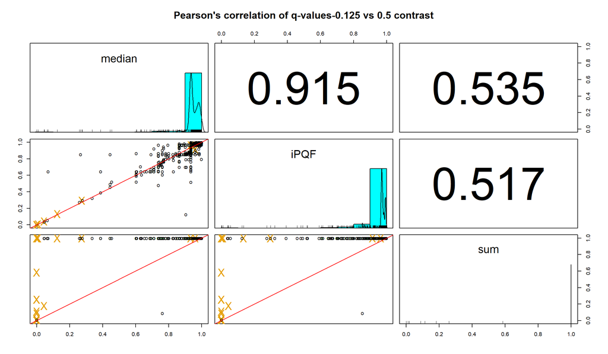

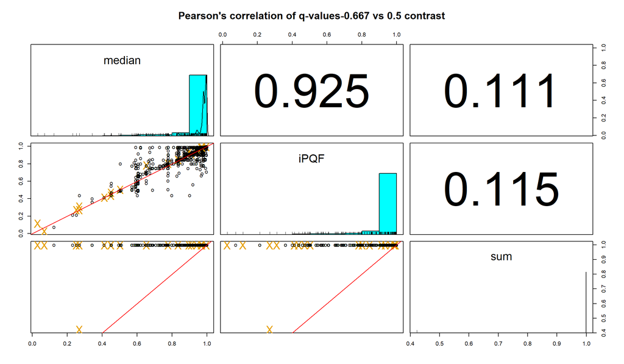

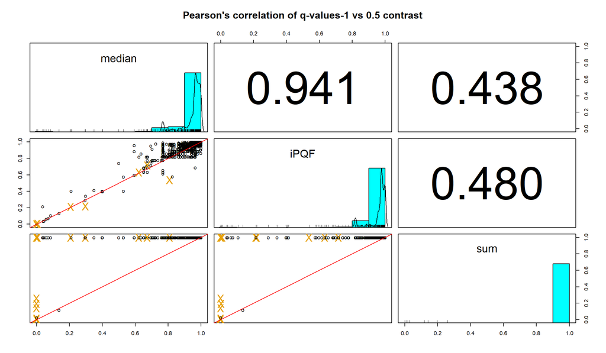

```r
scatterplot_ils(dat.dea, significance.cols, 'q-values', spiked.proteins, referenceCondition)
```

The correlation metween Median summarization and iPQF is even higher for the fold changes: $>0.99$ for all conditions. This is to be expected based on the q-value plots, as a large difference in the test statistic can be due to a small difference in fold change. The plots involving Sum summarization have an anomaly around 0 fold change, and the values of the spike-in proteins are not very well correlated with those of the other methods.

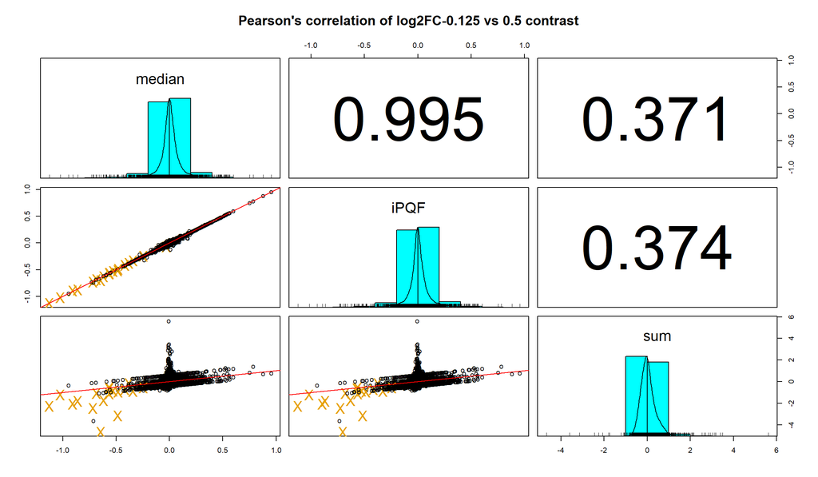

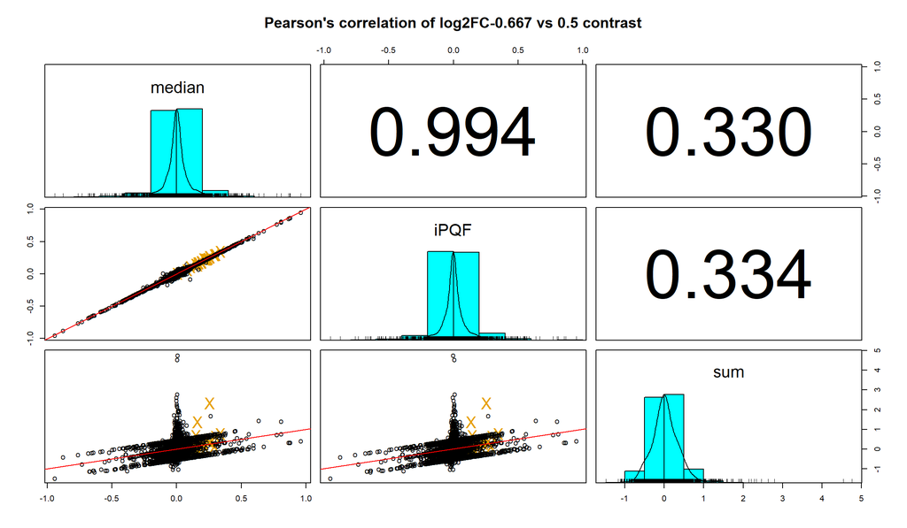

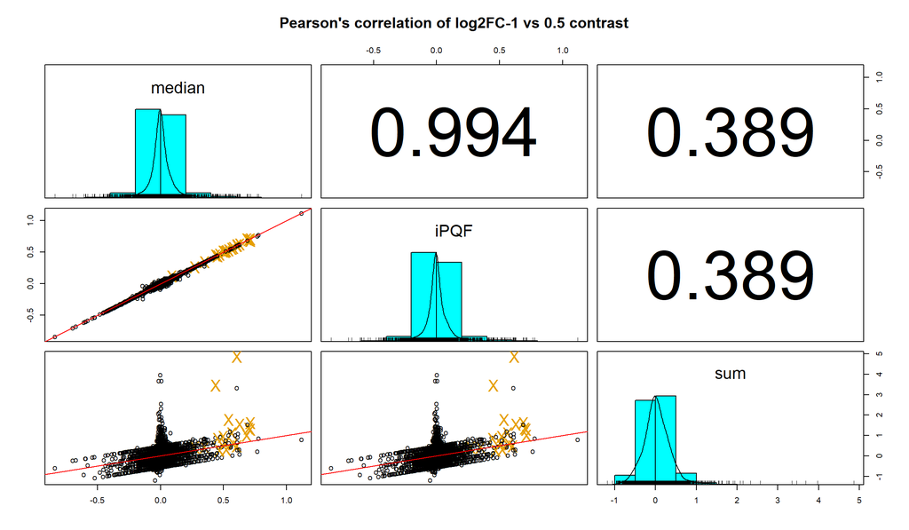

```r
scatterplot_ils(dat.dea, logFC.cols, 'log2FC', spiked.proteins, referenceCondition)
```

## 7.3 Volcano plots

The volcano plot combines information on fold changes and statistical significance. The spike-in proteins are colored blue, and immediately it is clear that their fold changes dominate the region of statistical significance, which suggests the experiment and analysis were carried out successfully. The magenta, dashed line indicates the theoretical fold change of the spike-ins.

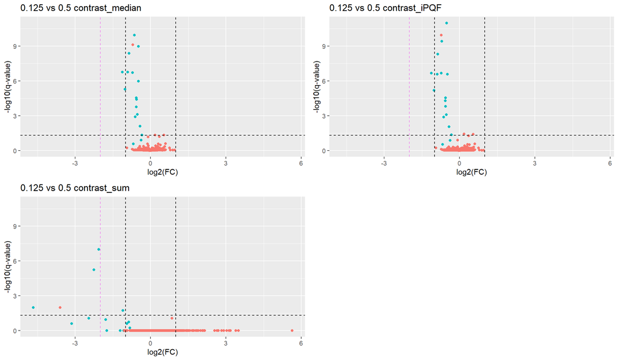

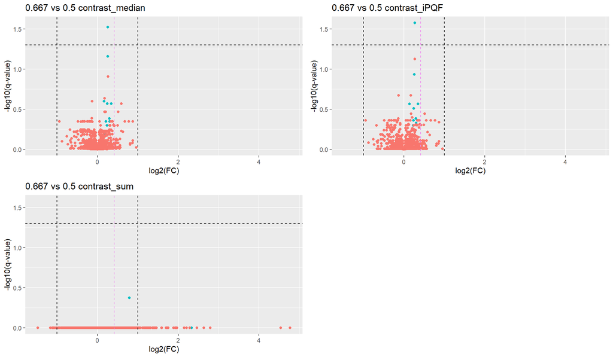

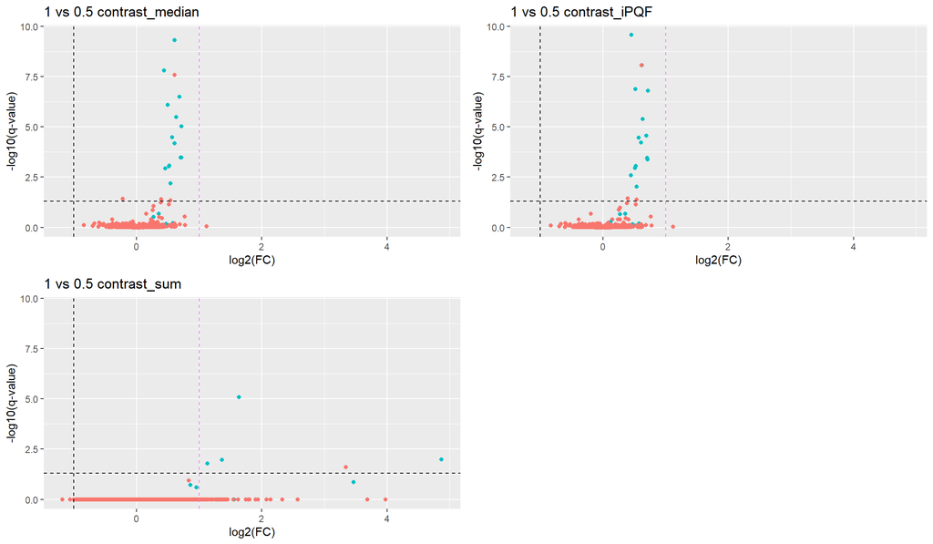

```r
for (i in 1:n.contrasts){
  volcanoplot_ils(dat.dea, i, spiked.proteins, referenceCondition)}
```

## 7.4 Violin plots

A good way to assess the general trend of the fold change estimates on a more ‘macroscopic’ scale is to make a violin plot. Ideally, there will be some spike-in proteins that attain the expected fold change (red dashed line) that corresponds to their condition, while most (background) protein log2 fold changes are situated around zero.

It seems that Median summarization and iPQF produce very similar violins, while Sum summarization is again the odd one out. Even though the Sum-associated values are closer to their theoretically expected values, in light of the rest of our analysis it seems more plausible that this is due to the entire distribution suffering increased variability, rather than that the Sum summarization would produce more reliable outcomes.

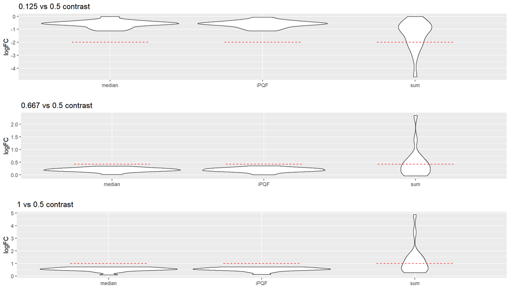

```r
# plot theoretical value (horizontal lines) and violin per variant
if (length(spiked.proteins)>0) violinplot_ils(lapply(dat.dea, function(x) x[spiked.proteins, logFC.cols]), referenceCondition) else violinplot_ils(lapply(dat.dea, function(x) x[,logFC.cols]), referenceCondition,  show_truth = FALSE)
```

# 8 Conclusions

For the given data set, the differences in proteomic outcomes between Median and iPQF normalization are quite small, both on the global and individual scale. Their differences with the Sum summarization outcomes are very large.

The QC plots suggest that the Sum summarization obfuscates much of the work done by the normalization. That is because it is inherently incompatible with (additive) median sweeping, or any other normalization method that produces negative values, as they lead to artifacts and blatantly incorrect outcomes. That said, one could even expect Sum summarization to perform improperly even with compatible normalization methods (e.g., multiplicative median sweeping on intensity-scale data), since it promotes not only *abundant* detections (at the PSM level) of proteins, but also *repeated* detections. Since repetition of detections in MS experiments is far from robust across runs, this is expected to introduce a great amount of stochasticity. Therefore, Sum summarization would also not work when you have data from multiple runs, and it would be advised to use another summarization method instead.